# Above Ground Biomass (AGB) Estimation

## Summarizing AGB per Subplot with Custom Predicted Height (Hpred)

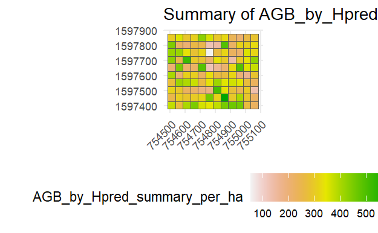

```r
subplot_metric04_perHA50_Hpred <- subplot_summary(
  subplots = subplots04_grid50_Hpred,
  value = "AGB_by_Hpred",
  per_ha = TRUE)
```

```r
subplot_polygons0.25_perHA_Hpred <- sf::st_set_crs(
 subplot_metric04_perHA50_Hpred$polygon ,
  value = "EPSG:32647")

sf::st_write(subplot_polygons0.25_perHA_Hpred,"C:/Users/rakir/OneDrive/Desktop/AGB_Project/Field/shp/polygon_C4_0.25HA_perHA_Hpred.shp")
```

```
G2;H2;Warningh in abbreviate_shapefile_names(obj) :
  Field names abbreviated for ESRI Shapefile driverg
```

```
Layer polygon_C4_0.25HA_perHA_Hpred in dataset C:/Users/rakir/OneDrive/Desktop/AGB_Project/Field/shp/polygon_C4_0.25HA_perHA_Hpred.shp already exists:
use either append=TRUE to append to layer or append=FALSE to overwrite layer
```

```
G1;H1;Errorh: Dataset already exists.
g
```

This block calculates the **total AGB per hectare** for each 50x50m subplot in the 2004 census, specifically using the AGB values calculated with the **custom predicted heights (`AGB_by_Hpred`)**.

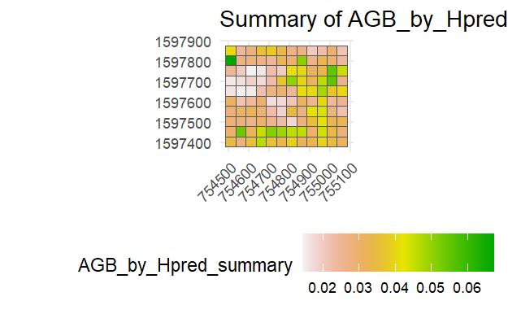

```r
subplot_metric04_sum50_Hpred <- subplot_summary(
  subplots = subplots04_grid50_Hpred,
  value = "AGB_by_Hpred",
  fun = quantile, probs = 0.5,
  per_ha = FALSE)
```

This block calculates the **median AGB per subplot** for the 50x50m grid in 2004.

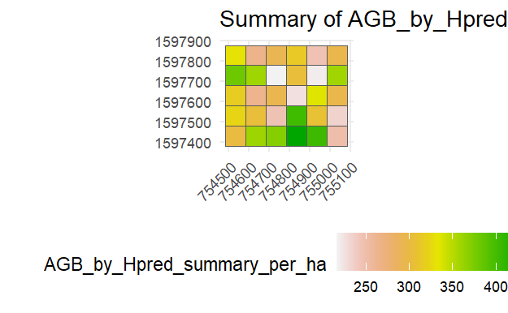

```r
subplot_metric04_perHA100_Hpred <- subplot_summary(
  subplots = subplots04_grid100_Hpred,
  value = "AGB_by_Hpred",
  per_ha = TRUE)
```

```r
subplot_polygons01_perHA_Hpred <- sf::st_set_crs(
 subplot_metric04_perHA100_Hpred$polygon ,
  value = "EPSG:32647")

sf::st_write(subplot_polygons01_perHA_Hpred,"C:/Users/rakir/OneDrive/Desktop/AGB_Project/Field/shp/polygon_C4_01HA_perHA_Hpred.shp")
```

```
G2;H2;Warningh in abbreviate_shapefile_names(obj) :
  Field names abbreviated for ESRI Shapefile driverg
```

```
Layer polygon_C4_01HA_perHA_Hpred in dataset C:/Users/rakir/OneDrive/Desktop/AGB_Project/Field/shp/polygon_C4_01HA_perHA_Hpred.shp already exists:
use either append=TRUE to append to layer or append=FALSE to overwrite layer
```

```
G1;H1;Errorh: Dataset already exists.
g
```

This block calculates the **total AGB per hectare** for each 100x100m subplot in the 2004 census, using `AGB_by_Hpred`.

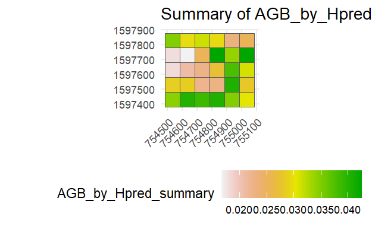

```r
subplot_metric04_sum100_Hpred <- subplot_summary(
  subplots = subplots04_grid100_Hpred,
  value = "AGB_by_Hpred",
  fun = quantile, probs = 0.5,
  per_ha = FALSE)
```

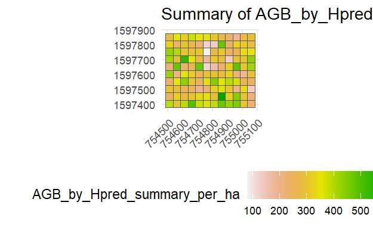

```r
subplot_metric05_perHA50_Hpred <- subplot_summary(
  subplots = subplots05_grid50_Hpred,
  value = "AGB_by_Hpred",
  per_ha = TRUE)
```

```r
subplot_polygons0.25_perHA_Hpred2 <- sf::st_set_crs(
 subplot_metric05_perHA50_Hpred$polygon ,
  value = "EPSG:32647")

sf::st_write(subplot_polygons0.25_perHA_Hpred2,"C:/Users/rakir/OneDrive/Desktop/AGB_Project/Field/shp/polygon_C5_0.25HA_perHA_Hpred.shp")
```

```
G2;H2;Warningh in abbreviate_shapefile_names(obj) :
  Field names abbreviated for ESRI Shapefile driverg
```

```
Layer polygon_C5_0.25HA_perHA_Hpred in dataset C:/Users/rakir/OneDrive/Desktop/AGB_Project/Field/shp/polygon_C5_0.25HA_perHA_Hpred.shp already exists:
use either append=TRUE to append to layer or append=FALSE to overwrite layer
```

```
G1;H1;Errorh: Dataset already exists.
g
```

This block calculates the **total AGB per hectare** for each 50x50m subplot in the Census 5, using `AGB_by_Hpred`.

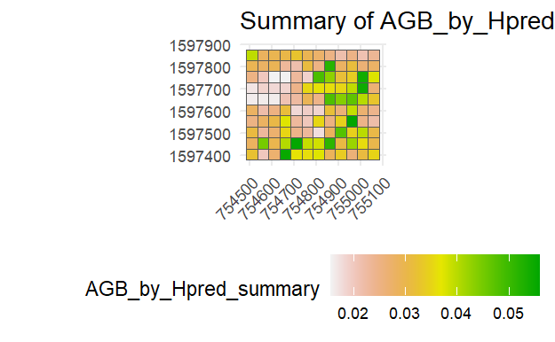

```r
subplot_metric05_sum50_Hpred <- subplot_summary(
  subplots = subplots05_grid50_Hpred,
  value = "AGB_by_Hpred",
  fun = quantile, probs = 0.5,
  per_ha = FALSE)
```

This block calculates the **median AGB per subplot** for the 50x50m grid in Census 5.

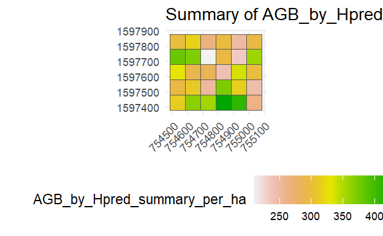

```r
subplot_metric05_perHA100_Hpred <- subplot_summary(
  subplots = subplots05_grid100_Hpred,
  value = "AGB_by_Hpred", # AGB was added before applying divide_plot()
  per_ha = TRUE)
```

```r
subplot_polygons01_perHA_Hpred2 <- sf::st_set_crs(
 subplot_metric05_perHA100_Hpred$polygon ,
  value = "EPSG:32647")

sf::st_write(subplot_polygons01_perHA_Hpred2,"C:/Users/rakir/OneDrive/Desktop/AGB_Project/Field/shp/polygon_C5_01HA_perHA_Hpred.shp")
```

```
G2;H2;Warningh in abbreviate_shapefile_names(obj) :
  Field names abbreviated for ESRI Shapefile driverg
```

```
Layer polygon_C5_01HA_perHA_Hpred in dataset C:/Users/rakir/OneDrive/Desktop/AGB_Project/Field/shp/polygon_C5_01HA_perHA_Hpred.shp already exists:
use either append=TRUE to append to layer or append=FALSE to overwrite layer
```

```
G1;H1;Errorh: Dataset already exists.
g
```

This block calculates the **total AGB per hectare** for each 100x100m subplot in the 2005 census, using `AGB_by_Hpred`.

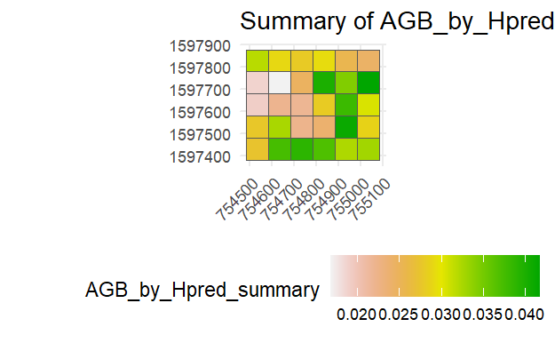

```r
subplot_metric05_sum100_Hpred <- subplot_summary(
  subplots = subplots05_grid100_Hpred,
  value = "AGB_by_Hpred",
  fun = quantile, probs = 0.5, # yes, it is the median
  per_ha = FALSE)
```

This block calculates the **median AGB per subplot** for the 100x100m grid in census 5.

## Visualizing AGB Change per Subplot (0.25 HA, Hpred)

```r
poly04 <- subplot_metric04_perHA50_Hpred$polygon
poly05 <- subplot_metric05_perHA50_Hpred$polygon
```

This block retrieves the `sf` polygon objects for the 50x50m subplots from the AGB per hectare summaries calculated using `AGB_by_Hpred`.

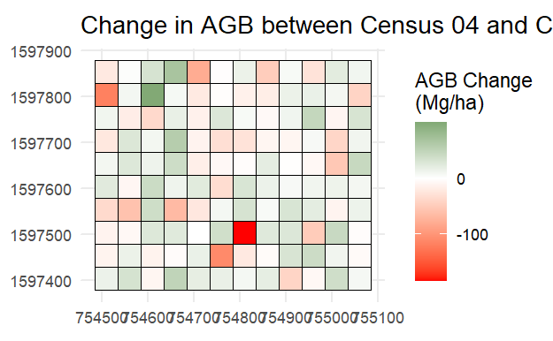

```r
poly04_df <- st_drop_geometry(poly04)
poly05_df <- st_drop_geometry(poly05)

agb_change <- poly04_df %>%
  inner_join(poly05_df, by = "subplot_ID", suffix = c("_04", "_05")) %>%
  mutate(AGB_change = AGB_by_Hpred_summary_per_ha_05 - AGB_by_Hpred_summary_per_ha_04)

agb_map <- left_join(poly04, agb_change, by = "subplot_ID")

agb_map <- poly04 %>%
  st_drop_geometry() %>%
  inner_join(agb_change, by = "subplot_ID") %>%
  left_join(poly04 %>%  dplyr::select(subplot_ID, sf_subplot_polygon), by = "subplot_ID") %>%
  st_as_sf()

ggplot(agb_map) +
  geom_sf(aes(fill = AGB_change), color = "black") +
  scale_fill_gradient2(
    low = "red", mid = "white", high = "darkgreen",
    midpoint = 0, name = "AGB Change\n(Mg/ha)"
  ) +
  labs(title = "Change in AGB between Census 04 and Census 05 (0.25 HA)") +
  theme_minimal()
```

This block calculates and visualizes the **change in AGB per hectare for each 50x50m subplot** between census 4 and 5, using the AGB values derived from the **custom predicted heights (`AGB_by_Hpred`)**. The process is identical to the previous AGB change map but uses the AGB values incorporating `Hpred`.

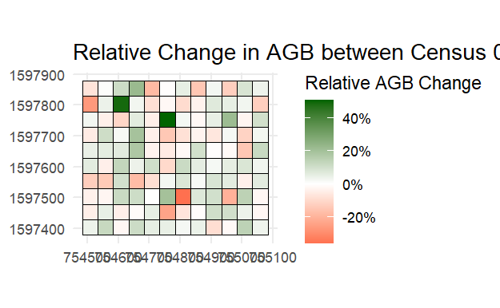

```r
# --- ส่วนของการเตรียมข้อมูลยังคงเดิม ---
poly04_df <- st_drop_geometry(poly04)
poly05_df <- st_drop_geometry(poly05)

# --- ปรับแก้ส่วนของการคำนวณ ---
agb_change <- poly04_df %>%
  inner_join(poly05_df, by = "subplot_ID", suffix = c("_04", "_05")) %>%
  mutate(
    # คำนวณการเปลี่ยนแปลงเชิงสัมพัทธ์ (Relative Change) เป็นทศนิยม
    # เพิ่ม ifelse เพื่อป้องกันการหารด้วยศูนย์
    AGB_change_relative = ifelse(
      AGB_by_Hpred_summary_per_ha_04 > 0,
      (AGB_by_Hpred_summary_per_ha_05 - AGB_by_Hpred_summary_per_ha_04) / AGB_by_Hpred_summary_per_ha_04,
      0
    )
  )

# --- ส่วนของการ join กลับไปยังข้อมูล sf ยังคงเดิม ---
agb_map <- poly04 %>%
  st_drop_geometry() %>%
  inner_join(agb_change, by = "subplot_ID") %>%
  left_join(poly04 %>%  dplyr::select(subplot_ID, sf_subplot_polygon), by = "subplot_ID") %>%
  st_as_sf()

# --- ปรับแก้ส่วนของการพล็อตกราฟ ---
ggplot(agb_map) +
  # เปลี่ยนมาใช้คอลัมน์ AGB_change_relative
  geom_sf(aes(fill = AGB_change_relative), color = "black") +

  # ปรับแก้ scale เพื่อจัดรูปแบบแกนสี
  scale_fill_gradient2(
    low = "red", mid = "white", high = "darkgreen",
    midpoint = 0,
    name = "Relative AGB Change", # เปลี่ยนชื่อแกน
    labels = scales::percent      # เพิ่มบรรทัดนี้เพื่อจัดรูปแบบเป็น %
  ) +

  # ปรับแก้ชื่อกราฟ
  labs(title = "Relative Change in AGB between Census 04 and Census 05 (0.25 HA)") +
  theme_minimal()
```

```r
# หากยังไม่ได้ติดตั้ง package 'scales' ให้รันคำสั่งนี้ใน Console หนึ่งครั้ง:
# install.packages("scales")
```

## Visualizing AGB Change per Subplot (1 HA, Hpred)

```r
poly04 <- subplot_metric04_perHA100_Hpred$polygon
poly05 <- subplot_metric05_perHA100_Hpred$polygon
```

This block retrieves the `sf` polygon objects for the 100x100m subplots from the AGB per hectare summaries calculated using `AGB_by_Hpred`.

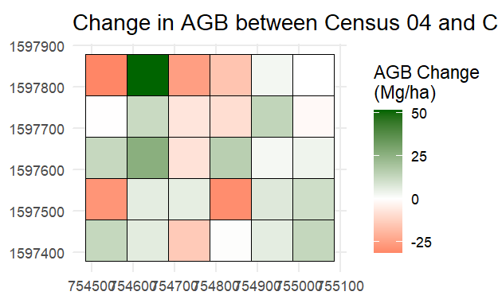

```r
poly04_df <- st_drop_geometry(poly04)
poly05_df <- st_drop_geometry(poly05)

agb_change <- poly04_df %>%
  inner_join(poly05_df, by = "subplot_ID", suffix = c("_04", "_05")) %>%
  mutate(AGB_change = AGB_by_Hpred_summary_per_ha_05 - AGB_by_Hpred_summary_per_ha_04)


agb_map <- left_join(poly04, agb_change, by = "subplot_ID")

agb_map <- poly04 %>%
  st_drop_geometry() %>%
  inner_join(agb_change, by = "subplot_ID") %>%
  left_join(poly04 %>%  dplyr::select(subplot_ID, sf_subplot_polygon), by = "subplot_ID") %>%
  st_as_sf()

ggplot(agb_map) +
  geom_sf(aes(fill = AGB_change), color = "black") +
  scale_fill_gradient2(
    low = "red", mid = "white", high = "darkgreen",
    midpoint = 0, name = "AGB Change\n(Mg/ha)"
  ) +
  labs(title = "Change in AGB between Census 04 and Census 05 (1 HA)") +
  theme_minimal()
```

This final block calculates and visualizes the **change in AGB per hectare for each 100x100m subplot** between census 4 and census 5, using the AGB values derived from the **custom predicted heights (`AGB_by_Hpred`)**. This provides a coarser-resolution spatial map of AGB change, serving as a final visualization of the forest’s biomass dynamics.

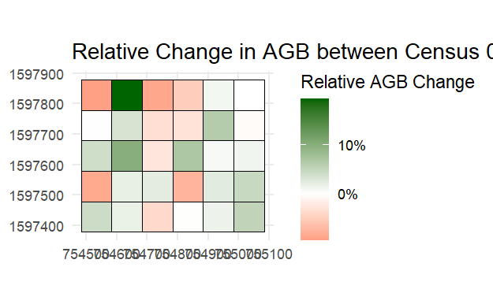

```r
# --- Data preparation remains the same ---
poly04_df <- st_drop_geometry(poly04)
poly05_df <- st_drop_geometry(poly05)

# --- 1. Adjust the calculation to be relative ---
agb_change <- poly04_df %>%
  inner_join(poly05_df, by = "subplot_ID", suffix = c("_04", "_05")) %>%
  mutate(
    # Calculate relative change: (new - old) / old
    # ifelse prevents division by zero
    AGB_change_relative = ifelse(
      AGB_by_Hpred_summary_per_ha_04 > 0,
      (AGB_by_Hpred_summary_per_ha_05 - AGB_by_Hpred_summary_per_ha_04) / AGB_by_Hpred_summary_per_ha_04,
      0
    )
  )

# --- Rejoining spatial data remains the same ---
agb_map <- poly04 %>%
  st_drop_geometry() %>%
  inner_join(agb_change, by = "subplot_ID") %>%
  left_join(poly04 %>%  dplyr::select(subplot_ID, sf_subplot_polygon), by = "subplot_ID") %>%
  st_as_sf()

# --- 2. Adjust the plot to show relative change ---
ggplot(agb_map) +
  # Use the new 'AGB_change_relative' column for the fill
  geom_sf(aes(fill = AGB_change_relative), color = "black") +

  # Update the scale and add percentage labels
  scale_fill_gradient2(
    low = "red", mid = "white", high = "darkgreen",
    midpoint = 0,
    name = "Relative AGB Change",
    labels = scales::percent # This formats labels as percentages
  ) +

  # Update the title
  labs(title = "Relative Change in AGB between Census 04 and Census 05 (1 HA)") +
  theme_minimal()
```

```r
# Note: You may need to run install.packages("scales") if you haven't already.
```

```r
sf_subplots04_50_Hpred <- subplot_metric04_perHA50_Hpred$polygon
sf_subplots04_100_Hpred <- subplot_metric04_perHA100_Hpred$polygon

sf_subplots05_50_Hpred <- subplot_metric05_perHA50_Hpred$polygon
sf_subplots05_100_Hpred <- subplot_metric05_perHA100_Hpred$polygon
```

```r
df_100_Hpred <- bind_rows(
  sf_subplots04_100_Hpred %>% st_drop_geometry() %>%
    mutate(Census = 4),
  sf_subplots05_100_Hpred %>% st_drop_geometry() %>%
    mutate(Census = 5)
)

df_50_Hpred <- bind_rows(
  sf_subplots04_50_Hpred %>% st_drop_geometry() %>%
    mutate(Census = 4),
  sf_subplots05_50_Hpred %>% st_drop_geometry() %>%
    mutate(Census = 5)
)
```

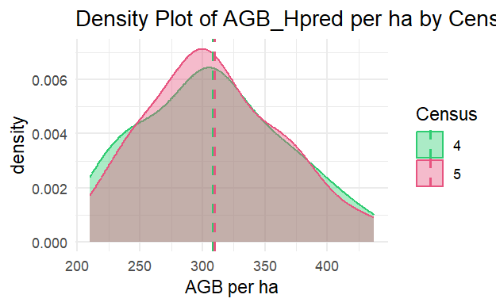

```r
ggplot(df_100_Hpred, aes(x = AGB_by_Hpred_summary_per_ha, fill = factor(Census), color = factor(Census))) +
  geom_density(alpha = 0.4) +
  geom_vline(data = df_100_Hpred %>% group_by(Census) %>%
               summarise(mu = mean(AGB_by_Hpred_summary_per_ha, na.rm = TRUE)),
             aes(xintercept = mu, color = factor(Census)),
             linetype = "dashed", size = 0.8) +
  scale_fill_manual(values = c("4" = "#2ECC71", "5" = "#E75480")) +
  scale_color_manual(values = c("4" = "#2ECC71", "5" = "#E75480")) +
  labs(
    title = "Density Plot of AGB_Hpred per ha by Census (1 HA)",
    x = "AGB per ha",
    fill = "Census",
    color = "Census"
  ) +
  theme_minimal()
```

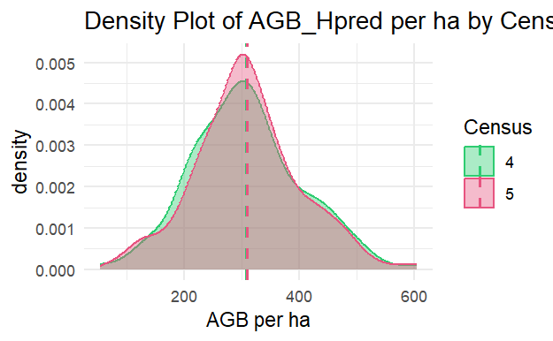

```r
ggplot(df_50_Hpred, aes(x = AGB_by_Hpred_summary_per_ha, fill = factor(Census), color = factor(Census))) +
  geom_density(alpha = 0.4) +
  geom_vline(data = df_50_Hpred %>% group_by(Census) %>%
               summarise(mu = mean(AGB_by_Hpred_summary_per_ha, na.rm = TRUE)),
             aes(xintercept = mu, color = factor(Census)),
             linetype = "dashed", size = 0.8) +
  scale_fill_manual(values = c("4" = "#2ECC71", "5" = "#E75480")) +
  scale_color_manual(values = c("4" = "#2ECC71", "5" = "#E75480")) +
  labs(
    title = "Density Plot of AGB_Hpred per ha by Census (0.25 HA)",
    x = "AGB per ha",
    fill = "Census",
    color = "Census"
  ) +
  theme_minimal()
```